# Grouping Pitchers by Pitch Arsenal Using PCA and Clustering

## Packages

```python
import pandas as pd
from sklearn.preprocessing import StandardScaler
from sklearn.decomposition import PCA
import matplotlib.pyplot as plt
import numpy as np
from sklearn.cluster import KMeans
from scipy.cluster.hierarchy import linkage, dendrogram, fcluster, set_link_color_palette
from sklearn.metrics import silhouette_score
```

## Data Cleanup

### Basic info

```python
# Load the dataset
file_path = '/content/pitch_type.csv'
data = pd.read_csv(file_path)

# Display initial structure for context
print("Initial Dataset Shape:", data.shape)
print(data.info())
print(data.head())
```

```
Initial Dataset Shape: (1106, 39)
<class 'pandas.core.frame.DataFrame'>
RangeIndex: 1106 entries, 0 to 1105
Data columns (total 39 columns):
 #   Column                  Non-Null Count  Dtype
---  ------                  --------------  -----
 0   last_name, first_name   1106 non-null   object
 1   player_id               1106 non-null   int64
 2   year                    1106 non-null   int64
 3   n_ff_formatted          1069 non-null   float64
 4   ff_avg_speed            1069 non-null   float64
 5   ff_avg_spin             1069 non-null   float64
 6   ff_avg_break_z_induced  1069 non-null   float64
 7   n_sl_formatted          818 non-null    float64
 8   sl_avg_speed            818 non-null    float64
```

[output cut: 69 more lines]

### Identify Pitch Usage Columns and Create Binary Flag

To ensure that pitchers who do not throw a certain pitch are represented appropriately, we create binary flags for each pitch type. These flags indicate whether a pitcher uses a particular pitch (1 for usage, 0 for non-usage). This step helps preserve meaningful information about the absence of specific pitches, which can be critical for clustering and analysis.

```python
# Identify columns related to pitch usage
pitch_columns = [col for col in data.columns if 'n_' in col]

# Create binary flags for each pitch type
for col in pitch_columns:
    flag_col = col.replace('n_', 'has_')
    data[flag_col] = data[col].notna().astype(int)

# Display new columns with binary flags
print("Sample Data with Binary Flags:")
print(data[[col for col in data.columns if 'has_' in col]].head())
```

```
Sample Data with Binary Flags:
   has_ff_formatted  has_sl_formatted  has_ch_formatted  has_cu_formatted  \
0                 1                 1                 1                 1
1                 1                 0                 1                 1
2                 1                 0                 0                 1
3                 1                 0                 1                 1
4                 1                 1                 1                 0

   has_si_formatted  has_fc_formatted  has_fs_formatted  has_st_formatted  \
0                 1                 0                 0                 0
1                 1                 0                 0                 0
2                 1                 1                 1                 0
3                 1                 1                 0                 0
4                 1                 1                 0                 0

   has_sv_formatted
0                 0
1                 0
2                 0
3                 0
4                 0
```

### Handle Missing Values by Imputation

Pitchers who do not throw a certain type of pitch naturally have missing data for related metrics (e.g., spin rate, speed). In this step, missing values in numeric columns are replaced with 0, explicitly indicating non-usage of that pitch. This ensures that clustering algorithms do not misinterpret missing values and that all pitchers are included in the analysis.

```python
# Identify numeric columns for imputation
numeric_columns = [col for col in data.columns if data[col].dtype == 'float64']

# Replace missing values in numeric columns with 0
data[numeric_columns] = data[numeric_columns].fillna(0)

# Verify imputation
print("Sample Data after Missing Value Imputation:")
print(data[numeric_columns].head())
```

```
Sample Data after Missing Value Imputation:
   n_ff_formatted  ff_avg_speed  ff_avg_spin  ff_avg_break_z_induced  \
0            29.1          90.9       2255.0                    15.5
1            11.7          91.7       2082.0                    12.0
2             7.0          88.5       2126.0                    11.8
3            26.4          84.5       2076.0                    12.1
4            25.2          90.8       2114.0                    14.7

   n_sl_formatted  sl_avg_speed  sl_avg_spin  sl_avg_break  n_ch_formatted  \
0             9.7          82.8       2178.0           6.3             7.4
1             0.0           0.0          0.0           0.0             8.8
2             0.0           0.0          0.0           0.0             0.0
3             0.0           0.0          0.0           0.0            21.1
4            22.5          79.6       1823.0          11.8            14.0

```

[output cut: 22 more lines]

### Standardize Numeric Data

Pitch metrics such as spin rate and speed vary widely in scale. To prevent clustering algorithms from being biased toward features with larger ranges, I will standardize the numeric data. Standardization transforms the data to have a mean of 0 and a standard deviation of 1, ensuring that all features contribute equally to the analysis.

```python
# Select columns for standardization (numeric and binary flags)
scaled_columns = numeric_columns + [col for col in data.columns if 'has_' in col]

# Standardize the selected columns
scaler = StandardScaler()
data[scaled_columns] = scaler.fit_transform(data[scaled_columns])

# Verify standardization
print("Sample Data after Standardization:")
print(data[scaled_columns].head())
```

```
Sample Data after Standardization:
   n_ff_formatted  ff_avg_speed  ff_avg_spin  ff_avg_break_z_induced  \
0       -0.211812      0.067336     0.193389                0.107785
1       -1.223574      0.114787    -0.210085               -0.838111
2       -1.496867     -0.075016    -0.107468               -0.892162
3       -0.368809     -0.312270    -0.224079               -0.811085
4       -0.438586      0.061405    -0.135454               -0.108420

   n_sl_formatted  sl_avg_speed  sl_avg_spin  sl_avg_break  n_ch_formatted  \
0       -0.318350      0.540557     0.435467      0.165177       -0.509354
1       -1.102058     -1.681349    -1.640706     -1.340870       -0.354382
2       -1.102058     -1.681349    -1.640706     -1.340870       -1.328491
3       -1.102058     -1.681349    -1.640706     -1.340870        1.007157
4        0.715822      0.454687     0.097064      1.479980        0.221228

```

[output cut: 22 more lines]

### Review dataset

```python
print("Final Cleaned Dataset Shape:", data.shape)
print(data.head())
```

```
Final Cleaned Dataset Shape: (1106, 48)
  last_name, first_name  player_id  year  n_ff_formatted  ff_avg_speed  \
0        Colon, Bartolo     112526  2015       -0.211812      0.067336
1         Burnett, A.J.     150359  2015       -1.223574      0.114787
2           Hudson, Tim     218596  2015       -1.496867     -0.075016
3         Buehrle, Mark     279824  2015       -0.368809     -0.312270
4          Sabathia, CC     282332  2015       -0.438586      0.061405

   ff_avg_spin  ff_avg_break_z_induced  n_sl_formatted  sl_avg_speed  \
0     0.193389                0.107785       -0.318350      0.540557
1    -0.210085               -0.838111       -1.102058     -1.681349
2    -0.107468               -0.892162       -1.102058     -1.681349
3    -0.224079               -0.811085       -1.102058     -1.681349
4    -0.135454               -0.108420        0.715822      0.454687

```

[output cut: 22 more lines]

## PCA

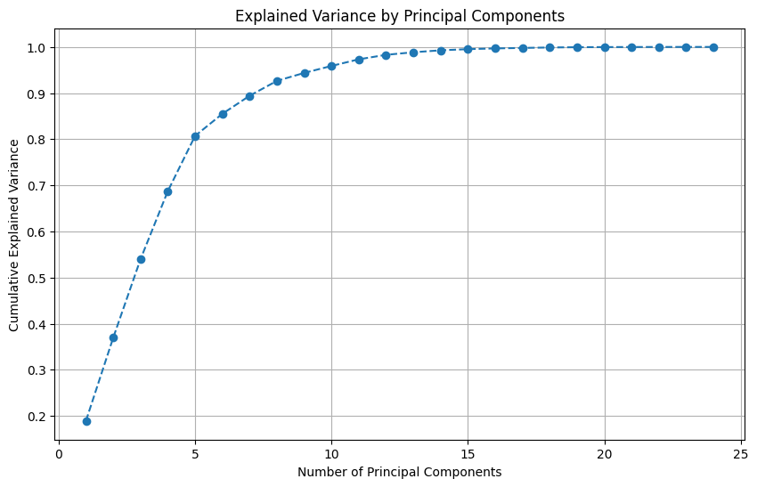

```python
# Select only numeric columns (including binary flags)
pca_columns = [col for col in data.columns if col.startswith(('ff_', 'sl_', 'cu_', 'si_', 'ch_', 'has_'))]

# Apply PCA
pca = PCA()
pca_result = pca.fit_transform(data[pca_columns])

# Explained variance
explained_variance = np.cumsum(pca.explained_variance_ratio_)

# Visualize the explained variance
plt.figure(figsize=(10, 6))
plt.plot(range(1, len(explained_variance) + 1), explained_variance, marker='o', linestyle='--')
plt.title('Explained Variance by Principal Components')
plt.xlabel('Number of Principal Components')
plt.ylabel('Cumulative Explained Variance')
plt.grid()
plt.show()
```

1. **Cumulative Explained Variance**:
   - The y-axis represents the cumulative percentage of the total variance in the dataset explained by the principal components.
   - The x-axis shows the number of principal components.
2. **Key Observations**:
   - The curve rises steeply at first, indicating that the first few components explain a large proportion of the variance in the dataset.
   - After about **6 components**, the curve begins to flatten, meaning that additional components contribute less to the total variance.
   - By **10 components**, the cumulative explained variance exceeds **90%**, suggesting that these 10 components capture most of the dataset's structure.
3. **Choosing the Number of Components**:
   - Typically, the number of components is chosen where the cumulative variance reaches a satisfactory level (e.g., 90%).
   - From the plot, retaining the first **10 components** is a reasonable choice, as they explain over 90% of the variance.
4. **Dimensionality Reduction**:
   - By reducing the dataset from potentially dozens of features to these **10 principal components**, you retain the key information while discarding less important variability. This makes subsequent clustering more computationally efficient and interpretable.

### Feature contributions

```python
print("Feature contributions to PC2:")
print(components.loc['PC2'].sort_values(ascending=False).head())
```

```
Feature contributions to PC2:
ff_avg_spin               0.304537
ff_avg_speed              0.292026
ff_avg_break_z_induced    0.291926
has_ff_formatted          0.287610
ch_avg_break              0.241365
Name: PC2, dtype: float64
```